# Part II - Factors Contributing to Borrowers APR and amount borrowed

## by Johnny Samuel

## Investigation Overview

> Prosper Loan is an organisation that seeks to provide loan for it's customers are a certain rate. We hope to use the data of each borrower to understand the factors that may have contributed to the present status of each borrower. This is aimed at analysing the factors that could affect the borrowers APR and the original amount that was given to the borrower.

## Dataset Overview

> This data set contains 113,937 loans with 81 variables on each loan, including loan amount, borrower rate (or interest rate), current loan status, borrower income, and many others.

It is worthy of note that we have time as a limitation which will not permit us to analyse all the the columns listed. Our focus will be on the borrowers APR and Borrowers status

## What can be said about the borrowers APR based on the statistics of borrowers?

We observe that the histogram is skewed to the right with an outlier at 0.35 which may be error

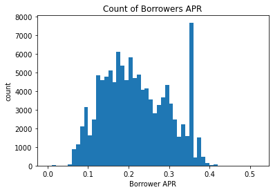

> It is observed that it is negatively correlated that is a decrease in the loan amount leads to an increase in the BorrowerAPR

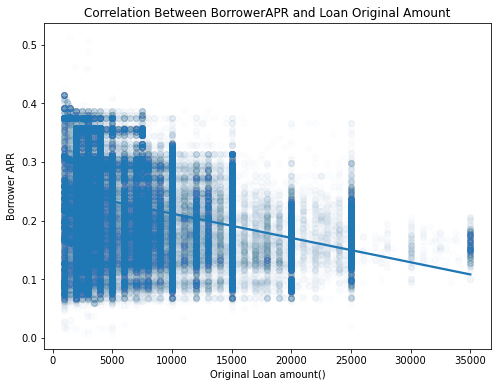

### what is the Relationship of Borrower Rate with Employment Status, Prosper Rating and Wage Group?

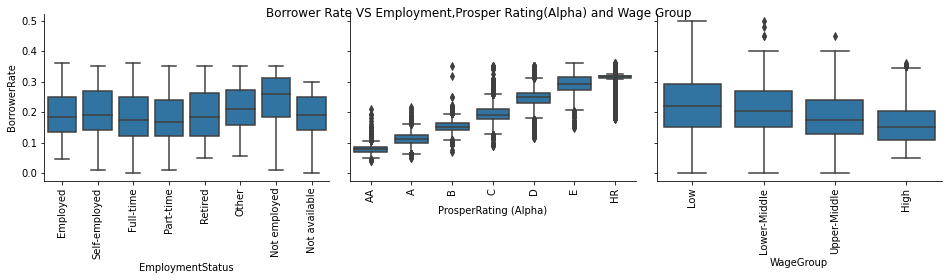

### What is the Relationship Between Wage Group, Original Loan Amount and Term?

> Its observed that those with higher term also borrow higher amount and also the higher the borrowers income the higher the term and the higher the amount borrowed, this should be because of the collateral they have.

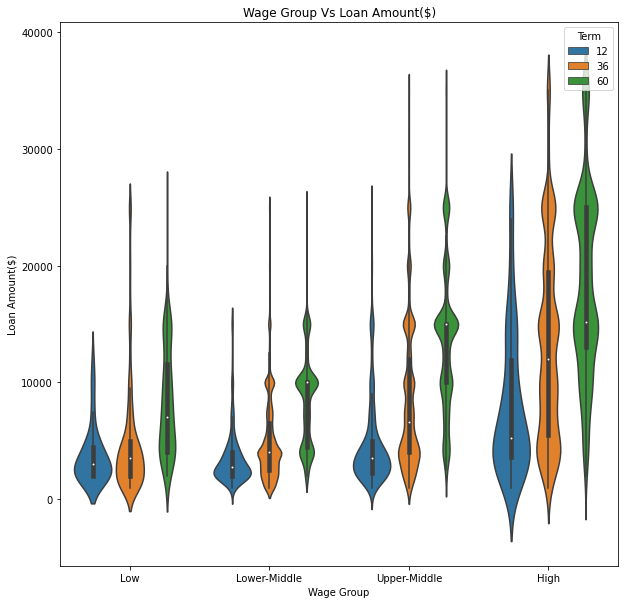